# Predict Defaulted Loans

## Khanh TRUONG

##### June 2019

The goal of this project is to analyze and predict if a loan is defaulted.

### Table of Contents:

1. Prepare Data
2. Descriptive Statistics
3. Machine Learning Models
   - Logistic Regression
   - Support Vector Machine
   - Random Forest

**Tips: It's recommended to follow the figures and their following comments only. There is no need to follow every single cell of code.**

```python
# Import necessary packages

# General metric and data frame manipulation
import numpy as np
import pandas as pd

# Visualization
import matplotlib.pyplot as plt
import seaborn as sns
sns.set()

# Dimension reduction
from sklearn.decomposition import PCA
from sklearn.manifold import TSNE

# Classification
from sklearn.model_selection import train_test_split

from sklearn.ensemble import RandomForestClassifier
from sklearn.linear_model import LogisticRegression
from sklearn.svm import SVC

from sklearn.model_selection import GridSearchCV
from sklearn.metrics import confusion_matrix
from sklearn.metrics import f1_score, make_scorer # create custom scorer for GridSearchCV
```

## 1. Prepare Data ============================================================

### Import data and filter appropriate subdata

```python
# Import data from my GitHub Page
# url = "https://raw.githubusercontent.com/truongphanduykhanh/Loan-Default-Prediction/master/prosperLoanData.csv"
url = 'prosperLoanData.csv'
loan = pd.read_csv(url)

# choose relevant columns based on financial expertise
loan = loan[["LoanStatus", "CreditGrade", "Term", "BorrowerAPR", "ProsperScore",
             "BorrowerState", "EmploymentStatus", "EmploymentStatusDuration", "IsBorrowerHomeowner",
             "CreditScoreRangeLower", "CreditScoreRangeUpper", "OpenCreditLines",
             "DelinquenciesLast7Years", "PublicRecordsLast12Months", "RevolvingCreditBalance",
             "AvailableBankcardCredit", "DebtToIncomeRatio", "IncomeRange", "TotalProsperLoans",
             "TotalProsperPaymentsBilled", "ProsperPaymentsLessThanOneMonthLate", "ProsperPaymentsOneMonthPlusLate",
             "ProsperPrincipalBorrowed", "ScorexChangeAtTimeOfListing", "LoanOriginalAmount", "Recommendations",
             "InvestmentFromFriendsAmount"]]

# There are some variables in the dataset that are available only after a loan is determined Defaulted or Completed
# such as "LoanCurrentDaysDelinquent" and "AmountDelinquent". In fact, if we incoporate these variables into statistical models,
# We will obtain even 100% of accurary. However, it's non-sense to use these features to predict if a loan is defaulted.

# filter only loans whose status are determined (either 'Completed' or 'Defaulted')
loan = loan.loc[loan.LoanStatus.isin(['Completed', 'Defaulted'])]

# Encode the columns "IncomeRange" and "LoanStatus"
cleanup_nums = {"IncomeRange": {"$25,000-49,999": np.mean([25000, 49999]),
                                "$50,000-74,999": np.mean([50000, 74999]),
                                "$75,000-99,999": np.mean([75000, 99999]),
                                "$1-24,999": np.mean([1, 24999]),
                                '$100,000+': 125000,
                                "$0": 0,
                                "Not employed": 0,
                                "Not displayed": np.nan},

                "LoanStatus": {"Completed": 0,
                               "Defaulted": 1}
               }

loan.replace(cleanup_nums, inplace=True)

# Encode the columns 'CreditScoreRangeLower' and 'CreditScoreRangeUpper'
loan['CreditScore'] = (loan['CreditScoreRangeLower'] + loan['CreditScoreRangeUpper'])/2
loan.drop(['CreditScoreRangeLower', 'CreditScoreRangeUpper'], axis=1, inplace=True)


loan.rename(columns={'LoanStatus':'Defaulted'}, inplace=True)

loan.head()
```

|  | Defaulted | CreditGrade | Term | BorrowerAPR | ProsperScore | BorrowerState | EmploymentStatus | EmploymentStatusDuration | IsBorrowerHomeowner | OpenCreditLines | ... | TotalProsperLoans | TotalProsperPaymentsBilled | ProsperPaymentsLessThanOneMonthLate | ProsperPaymentsOneMonthPlusLate | ProsperPrincipalBorrowed | ScorexChangeAtTimeOfListing | LoanOriginalAmount | Recommendations | InvestmentFromFriendsAmount | CreditScore |
| --- | --- | --- | --- | --- | --- | --- | --- | --- | --- | --- | --- | --- | --- | --- | --- | --- | --- | --- | --- | --- | --- |
| 0 | 0 | C | 36 | 0.16516 | NaN | CO | Self-employed | 2.0 | True | 4.0 | ... | NaN | NaN | NaN | NaN | NaN | NaN | 9425 | 0 | 0.0 | 649.5 |
| 2 | 0 | HR | 36 | 0.28269 | NaN | GA | Not available | NaN | False | NaN | ... | NaN | NaN | NaN | NaN | NaN | NaN | 3001 | 0 | 0.0 | 489.5 |
| 11 | 0 | C | 36 | 0.15033 | NaN | NaN | Full-time | 19.0 | False | 2.0 | ... | NaN | NaN | NaN | NaN | NaN | NaN | 1000 | 0 | 0.0 | 649.5 |
| 15 | 1 | NaN | 36 | 0.35797 | 5.0 | FL | Other | 121.0 | True | 9.0 | ... | NaN | NaN | NaN | NaN | NaN | NaN | 4000 | 0 | 0.0 | 709.5 |
| 21 | 0 | D | 36 | 0.21488 | NaN | MI | Full-time | 36.0 | False | 4.0 | ... | NaN | NaN | NaN | NaN | NaN | NaN | 3000 | 0 | 0.0 | 629.5 |

5 rows × 26 columns

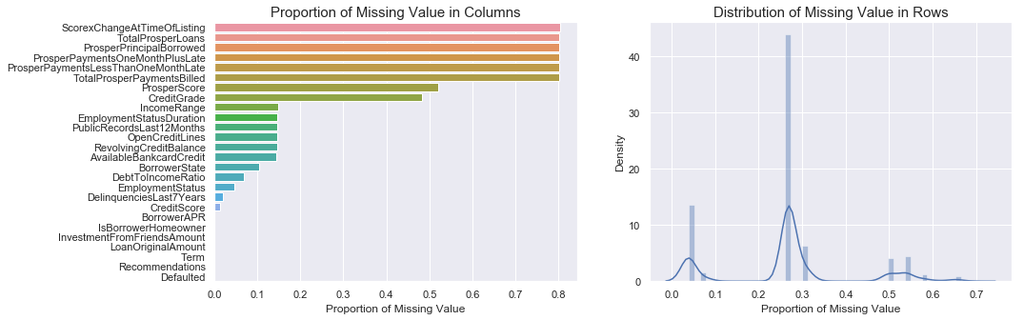

```python
# Count missing in every column and row

na_col = loan.isna().sum(axis=0).divide(loan.shape[0])
na_row = loan.isna().sum(axis=1).divide(loan.shape[1])

plt.figure(figsize=(15, 5))

plt.subplot(1, 2, 1)
sns.barplot(x=na_col.sort_values(ascending=False),
            y=na_col.sort_values(ascending=False).index)
plt.title('Proportion of Missing Value in Columns', size=15)
plt.xlabel('Proportion of Missing Value');

plt.subplot(1, 2, 2)
sns.distplot(na_row)
plt.title('Distribution of Missing Value in Rows', size=15)
plt.xlabel('Proportion of Missing Value')
plt.ylabel('Density');
```

*Imputation for columns or rows where the majority are missing values are not reliable. Therefore, filter out columns and rows in which there are more than 20% and 40% of missing values, respectively.*

```python
loan = loan.loc[na_row<0.4, loan.columns[na_col<0.2]]
```

### Impute missing value

```python
# Impute missing value in categorical columns by 'Unknown'
cat_col = ['BorrowerState', 'EmploymentStatus', 'IsBorrowerHomeowner']
loan[cat_col] = loan[cat_col].fillna('Unknown')
loan[cat_col] = loan[cat_col].astype('category')

# Impute missing value in numeric columns by the means
loan.loc[:, loan.columns[~loan.columns.isin(cat_col)]] = loan.loc[:, loan.columns[~loan.columns.isin(cat_col)]].fillna(loan.mean())

print('The shape of final data is {}'.format(loan.shape))
loan.head()
```

```
The shape of final data is (36848, 18)
```

|  | Defaulted | Term | BorrowerAPR | BorrowerState | EmploymentStatus | EmploymentStatusDuration | IsBorrowerHomeowner | OpenCreditLines | DelinquenciesLast7Years | PublicRecordsLast12Months | RevolvingCreditBalance | AvailableBankcardCredit | DebtToIncomeRatio | IncomeRange | LoanOriginalAmount | Recommendations | InvestmentFromFriendsAmount | CreditScore |
| --- | --- | --- | --- | --- | --- | --- | --- | --- | --- | --- | --- | --- | --- | --- | --- | --- | --- | --- |
| 0 | 0 | 36 | 0.16516 | CO | Self-employed | 2.0 | True | 4.0 | 4.0 | 0.0 | 0.0 | 1500.0 | 0.17 | 37499.5 | 9425 | 0 | 0.0 | 649.5 |
| 11 | 0 | 36 | 0.15033 | Unknown | Full-time | 19.0 | False | 2.0 | 1.0 | 0.0 | 1220.0 | 2580.0 | 0.27 | 12500.0 | 1000 | 0 | 0.0 | 649.5 |
| 15 | 1 | 36 | 0.35797 | FL | Other | 121.0 | True | 9.0 | 0.0 | 0.0 | 9103.0 | 178.0 | 0.49 | 62499.5 | 4000 | 0 | 0.0 | 709.5 |
| 21 | 0 | 36 | 0.21488 | MI | Full-time | 36.0 | False | 4.0 | 5.0 | 0.0 | 134.0 | 1366.0 | 0.09 | 37499.5 | 3000 | 0 | 0.0 | 629.5 |
| 23 | 1 | 36 | 0.28032 | IL | Employed | 3.0 | False | 7.0 | 0.0 | 0.0 | 7975.0 | 607.0 | 0.39 | 37499.5 | 2000 | 0 | 0.0 | 689.5 |

*We could actually have used fancier methods to impute missing values for continuous variables such as k-NN or Matrix Factorization. There are, however, only few missing values remaining compared to the completed part. Therefore, the result would not be significantly improved.*

### Convert categorical variables to dummy variables

```python
# Split the data into categorial and numerical part

cat_col = ['BorrowerState', 'EmploymentStatus', 'IsBorrowerHomeowner'] # categorial columns
loan_cat = loan.loc[:, loan.columns.isin(cat_col)]
loan_num = loan.loc[:, loan.columns[~loan.columns.isin(cat_col)]]
```

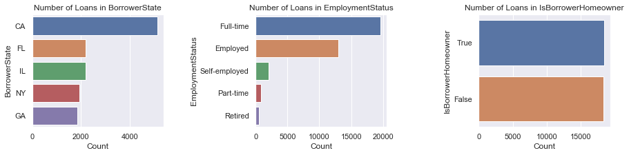

```python
# Display number of loans in every class of categorical variables

plt.figure(figsize=(15, 3))
for i in enumerate(loan_cat.columns):
    plt.subplots_adjust(wspace=0.7)
    plt.subplot(1, 3, i[0] + 1)
    sns.barplot(x=loan_cat[i[1]].value_counts()[0 : min(loan_cat[i[1]].nunique(), 5)],
                y=list(loan_cat[i[1]].value_counts()[0 : min(loan_cat[i[1]].nunique(), 5)].index.astype('str')))
    plt.title('Number of Loans in {}'.format(i[1]), size=12)
    plt.xlabel('Count')
    plt.ylabel(i[1]);
```

*There is a need of converting those categorical variables into dummies. Even though some statistical models can handle well categorical features (such as Random Forest), transforming into dummies makes it easier to compare all models' performance at once. It's straightforward to convert IsBorrowerHomeowner into one dummy variable because there are only two classes. For BorrowerState and EmploymentStatus, we need further analyze to group the classes efficiently.*

```python
# Calculate Defaulted Rate for every class of categorical variables

EmploymentStatus = pd.DataFrame({'DefaultedRate' : loan.groupby('EmploymentStatus').Defaulted.mean(),
                                 'NumberLoan' : loan.groupby('EmploymentStatus').Defaulted.count(),
                                 'PercentLoan' : loan.groupby('EmploymentStatus').Defaulted.count()/len(loan)
                                })
EmploymentStatus.sort_values('DefaultedRate', ascending=False, inplace=True)


BorrowerState = pd.DataFrame({'DefaultedRate' : loan.groupby('BorrowerState').Defaulted.mean(),
                              'NumberLoan' : loan.groupby('BorrowerState').Defaulted.count(),
                              'PercentLoan' : loan.groupby('BorrowerState').Defaulted.count()/len(loan)
                                })
BorrowerState.sort_values('DefaultedRate', ascending=False, inplace=True)
```

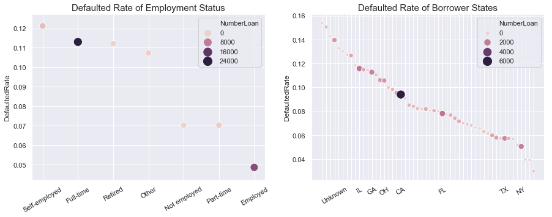

```python
# Display Defaulted Rate for every class of categorical variables

plt.figure(figsize=(15,5))

plt.subplot(1, 2, 1)
sns.scatterplot(x=EmploymentStatus.index,
                y='DefaultedRate',
                data=EmploymentStatus,
                hue='NumberLoan',
                size='NumberLoan',
                sizes=(100, 200))
plt.title('Defaulted Rate of Employment Status', size=15)
plt.xlabel(None)
plt.xticks(rotation=30);


plt.subplot(1, 2, 2)
g = sns.scatterplot(x=BorrowerState.index,
                    y='DefaultedRate',
                    data=BorrowerState,
                    hue='NumberLoan',
                    size='NumberLoan',
                    sizes=(20, 200))
plt.title('Defaulted Rate of Borrower States', size=15)
plt.xlabel(None)
plt.xticks(rotation=30)

# adjust the xstick so that it shows only big states
BorrowerState_xstick = BorrowerState.index.copy()
BorrowerState_xstick = list(BorrowerState_xstick)

for i in range(0, len(BorrowerState_xstick)):
    if BorrowerState_xstick[i] not in BorrowerState.NumberLoan[BorrowerState.NumberLoan.argsort()[-8:]]:
        BorrowerState_xstick[i] = '' # replace not most common names by blank

g.set_xticklabels(BorrowerState_xstick);
```

*For EmploymentStatus: It's faily surprised that Full-time job clients have higher Defaulted Rate compared to Not employed and Part-time. Nevertheless, we group Self-employed, Full-time, Retired and Other into one group. Not employed, Part-time and Employed to the other group.*

*For BorrowerState: Since there are nearly 5000 loans applied in California, we create a single group for CA. All other states which have lower Defaulted Rate than CA will be grouped together. Similarly, all the states which have higher Defaulted Rate will join in one cluster.*

```python
# Convert categorical variables in to dummies

# EmploymentStatus_0 = 1 if EmploymentStatus in ['Not employed', 'Part-time', 'Employed'], 0 otherwise
loan['EmploymentStatus_0'] = [int(x in ['Not employed', 'Part-time', 'Employed']) for x in loan['EmploymentStatus']]
loan = loan.drop(['EmploymentStatus'], axis=1)


# BorrowerState_CA = 1 if BorrowerState='CA'
# BorrowerState_0 = 1 if BorrowerState are those whose Defaulted Rate < Defaulted Rate of 'CA'
# BorrowerState_1 = 1 if BorrowerState are those whose Defaulted Rate > Defaulted Rate of 'CA'
BorrowerState_0 = BorrowerState.index[BorrowerState['DefaultedRate'] < BorrowerState.loc['CA', 'DefaultedRate']]
loan['BorrowerState_0'] = [int(x in BorrowerState_0) for x in loan['BorrowerState']]
loan['BorrowerState_CA'] = [int(x == 'CA') for x in loan['BorrowerState']]
loan = loan.drop(['BorrowerState'], axis=1)


# IsBorrowerHomeowner = 1 if IsBorrowerHomeowner='True'
loan['IsBorrowerHomeowner'] = loan['IsBorrowerHomeowner'].astype('bool').astype('int')
```

### Table of Contents:

1. Prepare Data
2. Descriptive Statistics
3. Machine Learning Models
   - Logistic Regression
   - Support Vector Machine
   - Random Forest

## 2. Descriptive Statistics =====================================================

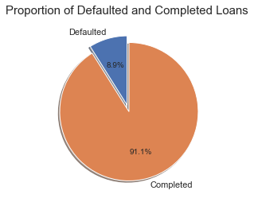

```python
# Distribution of target variable

plt.pie(x = [loan.Defaulted.sum(), len(loan)-loan.Defaulted.sum()],
        explode = (0, 0.1),
        labels = ['Defaulted', 'Completed'],
        autopct = '%1.1f%%',
        shadow = True,
        startangle = 90)
plt.title('Proportion of Defaulted and Completed Loans', size=15);
```

*8.9% of the loans in the data set are Defaulted ones. This is not an extremely unbalanced problem, which means we have an appropriate (adequate) proportion of labels for machine learning models. Otherwise, we have to deal with unbalanced data problem. Nevertheless, we are going to introduce sample weights (class weights) in the models, mainly because we want to stay away from False Negative prediction (discuss more later).*

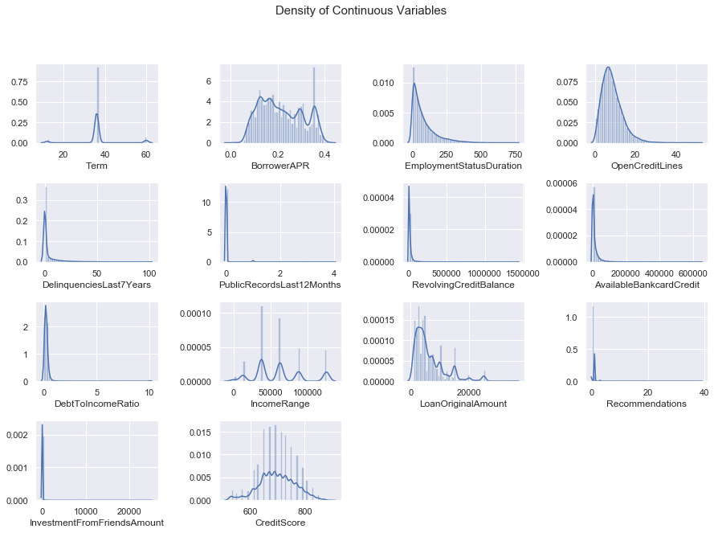

```python
# Density of numeric (continuous) variables

loan_num = loan.drop(['Defaulted', 'EmploymentStatus_0', 'BorrowerState_0', 'BorrowerState_CA', 'IsBorrowerHomeowner'], axis=1)
plt.figure(figsize=(15,10))
for i in enumerate(loan_num.columns):
    plt.subplot(4, 4, i[0] + 1)
    plt.subplots_adjust(hspace=0.5, wspace=0.5)
    sns.distplot(loan_num[i[1]])
plt.suptitle('Density of Continuous Variables', size=15);
```

*It seems that there are some extreme values in the dataset (not yet outliners). However, we are very conservative in removing those extreme values because it may lead to a bias result, and therefore do not reflect the behaviour of some clients in practice. Moreover, those extreme values do not pop-up individually but happen gradually, i.e. there is always an observation in the between of the extreme value and the mass. Given no additional information, we keep all the observations.*

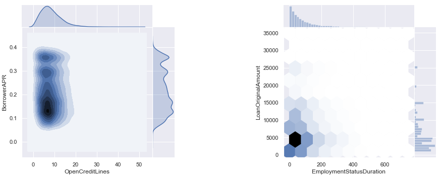

```python
# Bivatiate Distribution

JG1 = sns.jointplot(x = "OpenCreditLines",
                    y = "BorrowerAPR",
                    data = loan_num,
                    kind = "kde");
plt.close()

JG2 = sns.jointplot(x = "EmploymentStatusDuration",
                    y = "LoanOriginalAmount",
                    data = loan_num,
                    kind = "hex",
                    joint_kws=dict(gridsize=10));
plt.close()


#subplots migration
f = plt.figure(figsize=(30,10))
for J in [JG1, JG2]:
    for A in J.fig.axes:
        f._axstack.add(f._make_key(A), A)

#subplots size adjustment
f.axes[0].set_position([0.1, 0.1, 0.6, 0.6])
f.axes[1].set_position([0.1, 0.7, 0.6, 0.1])
f.axes[2].set_position([0.7, 0.1, 0.1, 0.6])
f.axes[3].set_position([1.3, 0.1, 0.6, 0.6])
f.axes[4].set_position([1.3, 0.7, 0.6, 0.1])
f.axes[5].set_position([1.9, 0.1, 0.1, 0.6])
```

*"OpenCreditLines" and "BorrowerAPR" are quite independent, i.e. "BorrowerAPR" varies almost in the vertical (orthogonal) direction to "OpenCreditLines". Moreover, it's interesting that there are some local peak in the density of "BorrowerAPR". The larger value peaks may contains more Defaulted Loans and turn it to become an important feature.*

*There is not a clear direction of bivariate density of "EmploymentStatusDuration" and "LoanOriginalAmount". It is mainly because both variables condense at the low values and have long tails.*

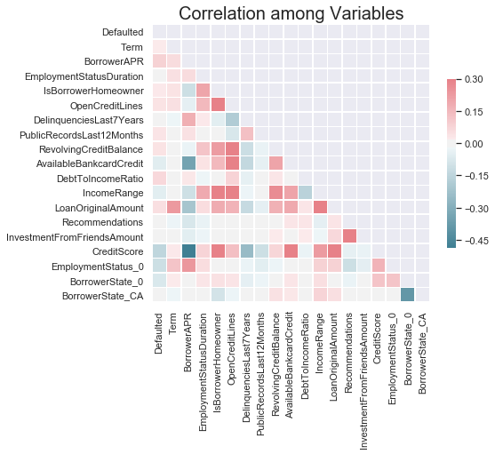

```python
# Correlation among variables

# Compute the correlation matrix
corr = loan.corr()

# Generate a mask for the upper triangle
mask = np.zeros_like(corr, dtype=np.bool)
mask[np.triu_indices_from(mask)] = True

# Set up the matplotlib figure
f, ax = plt.subplots(figsize=(7, 7))

# Generate a custom diverging colormap
cmap = sns.diverging_palette(220, 10, as_cmap=True)

# Draw the heatmap with the mask and correct aspect ratio
sns.heatmap(corr, mask=mask, cmap=cmap, vmax=.3, center=0,
            square=True, linewidths=.5, cbar_kws={"shrink": .5})
plt.title('Correlation among Variables', size=20);
```

*The heat map of correlation matrix gives a hint to determine important variables. A variable which is highly correlated to "Defaulted", either negatively or positively, can be the key feature to distinguish Defaulted loans from non-Defaulted ones. Particularly, BorrowerAPR, DebtToIncomeRatio and CreditScore are the most correlated aspects to Defaulted loans.*

*Moreover, the heat map also allows us to detect redundant variables, if any, when the correlation between any two variables approaches 1 or -1. The maximum absolute correlation values in our case is nearly 0.5 which is not extremely high, therefore we can keep all the variables for the statistical models.*

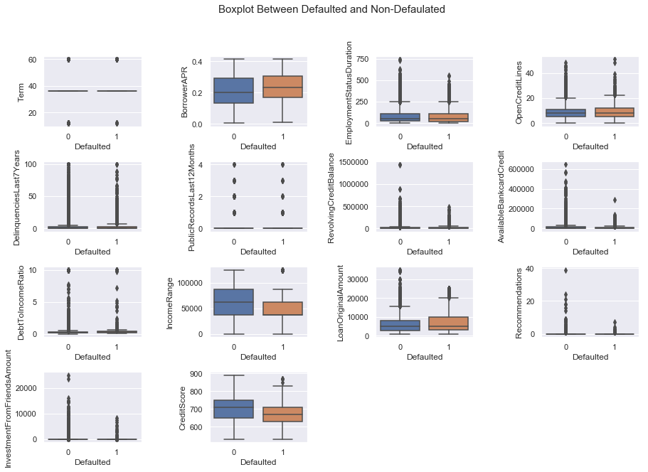

```python
# Compare distribution of numeric variables between 2 targeted labels

plt.figure(figsize=(15, 10))
for i in enumerate(loan_num.columns):
    plt.subplot(4, 4, i[0] + 1)
    plt.subplots_adjust(hspace=0.5, wspace=0.7)
    sns.boxplot(y = loan_num[i[1]],
                x = loan.Defaulted, orient = 'v')

plt.suptitle('Boxplot Between Defaulted and Non-Defaulated', size=15);
```

*Generally, there is no significant difference between the 2 classes of label in numeric variables.*

```python
# Normalize data (this step is essential for PCA and t-SNE because it harmonize the importance of all variables)

mean_normalize = loan.drop('Defaulted', axis=1).mean()
std_normalize = loan.drop('Defaulted', axis=1).std()
loan_scaled = (loan.drop('Defaulted', axis=1) - mean_normalize) / std_normalize
loan_scaled['Defaulted'] = loan['Defaulted'].copy()
```

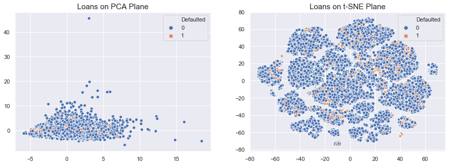

```python
# Represent data on 2D planes

plt.figure(figsize=(15, 5))

plt.subplot(1, 2, 1)
pca = PCA(n_components=2)
pca = pca.fit_transform(loan_scaled.drop('Defaulted', axis=1))
sns.scatterplot(x = [x[0] for x in pca],
                y = [x[1] for x in pca],
                hue = loan_scaled['Defaulted'].astype('category'),
                style=loan_scaled['Defaulted'].astype('category'))
plt.title('Loans on PCA Plane', size=15);


plt.subplot(1, 2, 2)
t_sne = TSNE(n_components=2, random_state=42)
t_sne = t_sne.fit_transform(loan_scaled.drop('Defaulted', axis=1))
sns.scatterplot(x=[x[0] for x in t_sne],
                y=[x[1] for x in t_sne],
                hue=loan_scaled['Defaulted'].astype('category'),
                style=loan_scaled['Defaulted'].astype('category'))
plt.title('Loans on t-SNE Plane', size=15);
```

*PCA (Principal component analysis) plane depicts some extreme values in the data set. It doesn't, however, separate well the group Defaulted and Not Defaulted. Theoretically, it's completely understandable because PCA only tries to represent the most variation of the data regardless the observations’ labels. Moreover, the above PCA plane explains only 25% variation of the data.*

*On the other hand, rather than stretching the overall variation, t-SNE (t-distributed stochastic neighbor embedding) - a fairly recent method to reduce dimensions of data, tries to maximize the local variation. Nonetheless, it is not able to tell which part of the plane contains more Defaulted Loans. The heavily overlapping of labels in PCA and t-SNE may be a signal of difficulty in training the predictive models.*

### Table of Contents:

1. Prepare Data
2. Descriptive Statistics
3. Machine Learning Models
   - Logistic Regression
   - Support Vector Machine
   - Random Forest

## 3. Predictive Models =======================================================

### Train and test sets split

```python
# Split into train set and test set

X_train, X_test, y_train, y_test = train_test_split(loan_scaled.drop('Defaulted', axis=1),
                                                    loan_scaled['Defaulted'],
                                                    test_size = 0.2,
                                                    random_state = 42)
```

### Define score function for tuning parameters

*It is very important to note that there is a tremendous difference between False Negative (FN) and False Positive (FP) predictions in our problem. An actual defaulted loan predicted as non-defaulted (FN) may lead to a big loss for the company. On the other hand, a non-defaulted loan predicted as defaulted (FP), i.e. do not process the good loan, would only take a small potential interest away. Therefore, we put more weight on defaulted loans so that we minimize FN given an acceptable level of FP.*

*The weight may vary from one company to another. In this problem, we assume one defaulted loan causes a loss which is approximately equal to 20 completed loans. Therefore, we set the weight to be 1:20, i.e. roughly speaking 1 FN is as bad as 20 FP.*

```python
class_weight = {0:1, 1:20}
```

```python
# Following the class_weight, we define the score function in order to obtain the best model in term of this metric
# In fact, the metric is based on F1 Measure (F1 Score) with addition of class_weight

def f1_custom(y_true, y_pred, class_weight = {0:1, 1:20}):

    weight = class_weight[1]/class_weight[0]

    TP = sum([x==(1, 1) for x in zip(y_true, y_pred)]) # true positive
    FN = sum([x==(1, 0) for x in zip(y_true, y_pred)]) # false negative
    FP = sum([x==(0, 1) for x in zip(y_true, y_pred)]) # false positive
    TN = sum([x==(0, 0) for x in zip(y_true, y_pred)]) # true negative

    precision = TP*weight / (TP*weight + FP)
    recall = TP*weight / (TP*weight + FN*weight)
    f1_custom = 2 * precision * recall / (precision + recall)

    return f1_custom

f1_custom = make_scorer(f1_custom, greater_is_better=True) # convert the function into scorer
```

### Grid Search CV parameters

```python
# Set up models:

# Logistic regression
logit = LogisticRegression(random_state=42, solver='liblinear', multi_class='ovr', class_weight=class_weight)
logit_grid = GridSearchCV(logit,
                          param_grid={'penalty': ['l1', 'l2'],
                                      'tol': [1e-1, 1e-2, 1e-3],
                                      'C': np.logspace(-2, 2, 5)},
                          scoring=f1_custom,
                          return_train_score=True,
                          cv=5)

# Support vector machine
svm = SVC(random_state=42, gamma='auto', kernel='linear', class_weight=class_weight)
svm_grid = GridSearchCV(svm,
                        param_grid={'tol': [1e-2, 1e-3, 1e-4],
                                    'C': np.logspace(-1, 1, 3)},
                        scoring=f1_custom,
                        return_train_score=True,
                        cv=5)

# Random forest
forest = RandomForestClassifier(random_state=42, criterion='gini', class_weight=class_weight)
forest_grid = GridSearchCV(forest,
                           param_grid={'n_estimators': [30, 50, 100],
                                       'min_impurity_decrease': np.logspace(-7, -2, 6)},
                           scoring=f1_custom,
                           return_train_score=True,
                           cv=5)
```

```python
# Train the GridSearchCV

logit_grid.fit(X_train, y_train)
svm_grid.fit(X_train, y_train)
forest_grid.fit(X_train, y_train)
```

```
GridSearchCV(cv=5, error_score='raise-deprecating',
       estimator=RandomForestClassifier(bootstrap=True, class_weight={0: 1, 1: 20},
            criterion='gini', max_depth=None, max_features='auto',
            max_leaf_nodes=None, min_impurity_decrease=0.0,
            min_impurity_split=None, min_samples_leaf=1,
            min_samples_split=2, min_weight_fraction_leaf=0.0,
            n_estimators='warn', n_jobs=None, oob_score=False,
            random_state=42, verbose=0, warm_start=False),
       fit_params=None, iid='warn', n_jobs=None,
       param_grid={'n_estimators': [30, 50, 100], 'min_impurity_decrease': array([1.e-07, 1.e-06, 1.e-05, 1.e-04, 1.e-03, 1.e-02])},
       pre_dispatch='2*n_jobs', refit=True, return_train_score=True,
       scoring=make_scorer(f1_custom), verbose=0)
```

### Models' performance

```python
# Define a function that show the value on top of columns in barplot of Searborn

def add_value_labels(ax, spacing=0, formating="{:.1%}"):
    """Add labels to the end of each bar in a bar chart.

    Arguments:
        ax (matplotlib.axes.Axes): The matplotlib object containing the axes
            of the plot to annotate.
        spacing (int): The distance between the labels and the bars.
    """

    # For each bar: Place a label
    for rect in ax.patches:
        # Get X and Y placement of label from rect.
        y_value = rect.get_height()
        x_value = rect.get_x() + rect.get_width() / 2

        # Number of points between bar and label. Change to your liking.
        space = spacing
        # Vertical alignment for positive values
        va = 'bottom'

        # If value of bar is negative: Place label below bar
        if y_value < 0:
            # Invert space to place label below
            space *= -1
            # Vertically align label at top
            va = 'top'

        # Use Y value as label and format number with one decimal place
        label = formating.format(y_value)

        # Create annotation
        ax.annotate(
            label,                      # Use `label` as label
            (x_value, y_value),         # Place label at end of the bar
            xytext=(0, space),          # Vertically shift label by `space`
            textcoords="offset points", # Interpret `xytext` as offset in points
            ha='center',                # Horizontally center label
            va=va)                      # Vertically align label differently for
                                        # positive and negative values.
```

```python
# Extract the best mean_test_score and corresponding mean_train_score from GridSearchCV

test_score_logit = np.max(logit_grid.cv_results_['mean_test_score'])
test_score_svm = np.max(svm_grid.cv_results_['mean_test_score'])
test_score_forest = np.max(forest_grid.cv_results_['mean_test_score'])

train_score_logit = logit_grid.cv_results_['mean_train_score'][np.argmax(logit_grid.cv_results_['mean_test_score'])]
train_score_svm = svm_grid.cv_results_['mean_train_score'][np.argmax(svm_grid.cv_results_['mean_test_score'])]
train_score_forest = forest_grid.cv_results_['mean_train_score'][np.argmax(forest_grid.cv_results_['mean_test_score'])]

score_cv = pd.DataFrame({'Model': ['Logit', 'SVM', 'Forest'],
                         'Train': [train_score_logit, train_score_svm, train_score_forest],
                         'Test': [test_score_logit, test_score_svm, test_score_forest]})

score_cv = pd.melt(score_cv, id_vars="Model", var_name="Type", value_name='Score')
```

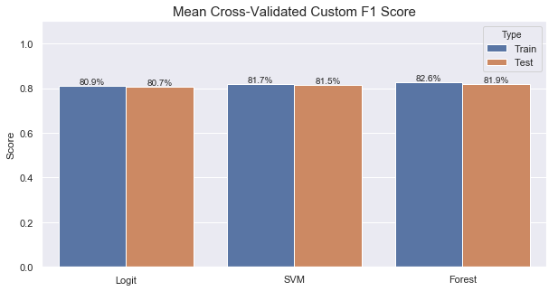

```python
# Display the best mean_test_score and corresponding mean_train_score from GridSearchCV

plt.figure(figsize=(10, 5))

ax = sns.barplot(x='Model',
                 y='Score',
                 hue='Type',
                 data=score_cv)
plt.title('Mean Cross-Validated Custom F1 Score', size=15)
plt.xlabel(None)
add_value_labels(ax, spacing=0)
plt.ylim(0, 1.1);
```

```python
# Create confusion matrix

list1 = ["Predicted 0", "Predicted 1"]
list2 = ["Actual 0", "Actual 1"]

confusion_logit = pd.DataFrame(confusion_matrix(logit_grid.predict(X_test), y_test), list1,list2)
confusion_svm = pd.DataFrame(confusion_matrix(svm_grid.predict(X_test), y_test), list1,list2)
confusion_forest = pd.DataFrame(confusion_matrix(forest_grid.predict(X_test), y_test), list1,list2)
```

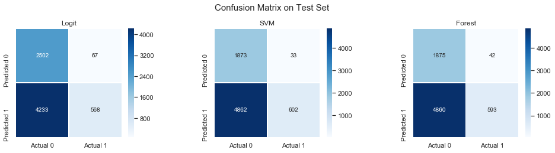

```python
# Display confusion matrix

plt.figure(figsize=(16, 3.2))
plt.subplots_adjust(wspace=0.5)

plt.subplot(1, 3, 1)
sns.heatmap(confusion_logit, annot=True, fmt="d", linewidths=.5, cmap='Blues')
plt.title('Logit', size=12);


plt.subplot(1, 3, 2)
sns.heatmap(confusion_svm, annot=True, fmt="d", linewidths=.5, cmap='Blues')
plt.title('SVM', size=12);


plt.subplot(1, 3, 3)
sns.heatmap(confusion_forest, annot=True, fmt="d", linewidths=.5, cmap='Blues')
plt.title('Forest', size=12);


plt.suptitle('Confusion Matrix on Test Set', size=15)
plt.subplots_adjust(top=0.8, bottom=0);
```

*People may claim that the performance of three models are very poor if they look at the F1 score and especially at the above confusion matrix. The majority of the predictions are False Positive. This is because we have discussed earlier that we have set the class weight 1:20 for non-Defaulted and Defaulted labels, respectively. As a result, the models are very conservative to make False Negative predictions (Predicted 0, Actual 1). If we haven't set the sample weight (class weight is 1:1 as origin), the F1 score and confusion matrix would have been much more 'beautiful' but there would be a lot more False Negative predictions.*

### Compared with non-weighted models

```python
# Set up models:

# Logistic regression
logit_1 = LogisticRegression(random_state=42, solver='liblinear', multi_class='ovr')


# Support vector machine
svm_1 = SVC(random_state=42, gamma='auto_deprecated', kernel='linear')

# Random forest
forest_1 = RandomForestClassifier(random_state=42, criterion='gini', n_estimators=50)
```

```python
# Train the models

logit_1.fit(X_train, y_train)
svm_1.fit(X_train, y_train)
forest_1.fit(X_train, y_train)
```

```
RandomForestClassifier(bootstrap=True, class_weight=None, criterion='gini',
            max_depth=None, max_features='auto', max_leaf_nodes=None,
            min_impurity_decrease=0.0, min_impurity_split=None,
            min_samples_leaf=1, min_samples_split=2,
            min_weight_fraction_leaf=0.0, n_estimators=50, n_jobs=None,
            oob_score=False, random_state=42, verbose=0, warm_start=False)
```

```python
# Create confusion matrix

list1 = ["Predicted 0", "Predicted 1"]
list2 = ["Actual 0", "Actual 1"]

confusion_logit_1 = pd.DataFrame(confusion_matrix(logit_1.predict(X_test), y_test), list1,list2)
confusion_svm_1 = pd.DataFrame(confusion_matrix(svm_1.predict(X_test), y_test), list1,list2)
confusion_forest_1 = pd.DataFrame(confusion_matrix(forest_1.predict(X_test), y_test), list1,list2)
```

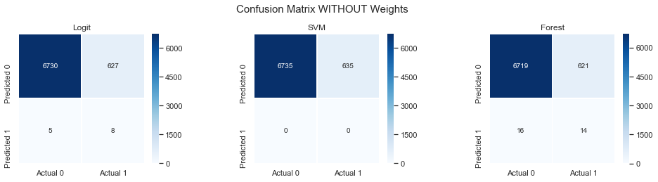

```python
# Display confusion matrix

plt.figure(figsize=(16, 3.2))
plt.subplots_adjust(wspace=0.5)

plt.subplot(1, 3, 1)
sns.heatmap(confusion_logit_1, annot=True, fmt="d", linewidths=.5, cmap='Blues')
plt.title('Logit', size=12);


plt.subplot(1, 3, 2)
sns.heatmap(confusion_svm_1, annot=True, fmt="d", linewidths=.5, cmap='Blues')
plt.title('SVM', size=12);


plt.subplot(1, 3, 3)
sns.heatmap(confusion_forest_1, annot=True, fmt="d", linewidths=.5, cmap='Blues')
plt.title('Forest', size=12);


plt.suptitle('Confusion Matrix WITHOUT Weights', size=15)
plt.subplots_adjust(top=0.8, bottom=0);
```

*If the class weights have been set to be 1:1 (no weights), the models would predict much more True Negative (Predicted 0, Actual 0) but they also commit far more False Negative predictions. Basically, the models would predict that almost all the loans are non-defaulted (especially SVM).*

### Financial context

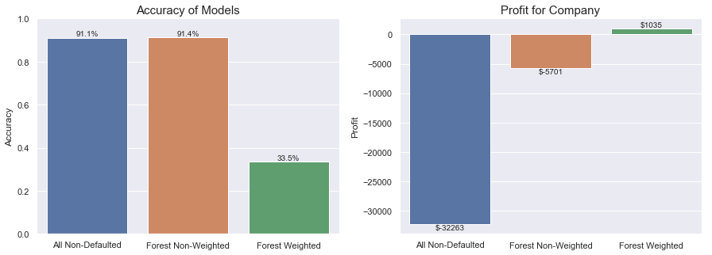

```python
# Assume one defaulted loan causes a loss as large as profit of 20 completed loans

accuracy = pd.DataFrame({'Model': ['All Non-Defaulted', 'Forest Non-Weighted', 'Forest Weighted'],

                         'Accuracy': [sum(loan_scaled['Defaulted']==0)/len(loan_scaled),
                                      (confusion_forest_1.loc['Predicted 0', 'Actual 0'] + confusion_forest_1.loc['Predicted 1', 'Actual 1'])/len(y_test),
                                      (confusion_forest.loc['Predicted 0', 'Actual 0'] + confusion_forest.loc['Predicted 1', 'Actual 1'])/len(y_test)]
                        })


profit = pd.DataFrame({'Model': ['All Non-Defaulted', 'Forest Non-Weighted', 'Forest Weighted'],

                       'Profit': [sum(loan_scaled.Defaulted == 0) - 20*sum(loan_scaled.Defaulted == 1),
                                  confusion_forest_1.loc['Predicted 0', 'Actual 0'] - 20*confusion_forest_1.loc['Predicted 0', 'Actual 1'],
                                  confusion_forest.loc['Predicted 0', 'Actual 0'] - 20*confusion_forest.loc['Predicted 0', 'Actual 1']]
                      })


# Display accuracy and profit comparison

plt.figure(figsize=(15, 5))


plt.subplot(1, 2, 1)
ax = sns.barplot(x='Model',
                 y='Accuracy',
                 data=accuracy)
plt.title('Accuracy of Models', size=15)
plt.ylim(0, 1)
add_value_labels(ax, spacing=0)
plt.xlabel(None);


plt.subplot(1, 2, 2)
bx = sns.barplot(x='Model',
                 y='Profit',
                 data=profit)
plt.title('Profit for Company', size=15)
add_value_labels(bx, spacing=0, formating="${:.0f}")
plt.xlabel(None);
```

*When we assume 1 True Negative prediction generate 1 dollar of profit, and one False Negative prediction causes 20 dollars of loss, then the weighted model performs greatly superior than non-weighted one even though the accuracy is lower.*

### Feature Importance

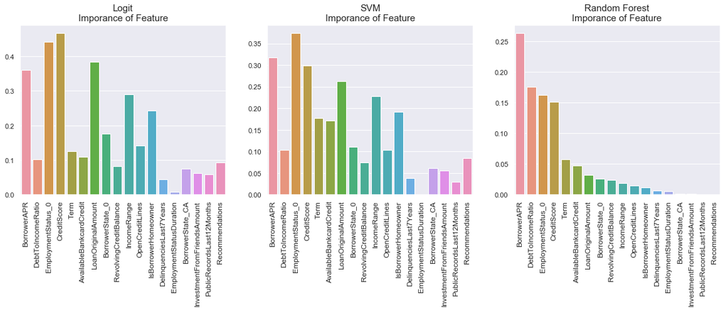

```python
# Meaningful variables

importance = pd.DataFrame([X_train.columns,
                           abs(logit_grid.best_estimator_.coef_[0]), # coefficients of logit model
                           abs(svm_grid.best_estimator_.coef_[0]), # coefficients of SVM
                           forest_grid.best_estimator_.feature_importances_]).transpose() # feature importance in random forest

importance.columns = ['Variable', 'Logit', 'SVM', 'Random Forest']
importance.sort_values('Random Forest', ascending=False, inplace=True)

# Plot the feature importances of the forest
plt.figure(figsize=(20, 5))
plt.subplot(1, 3, 1)
sns.barplot(x='Variable',
            y='Logit',
            data=importance)

plt.xticks(rotation=90, size=12)
plt.xlabel(None)
plt.ylabel(None)
plt.title('Logit\nImporance of Feature', size=15);


plt.subplot(1, 3, 2)
sns.barplot(x='Variable',
            y='SVM',
            data=importance)

plt.xticks(rotation=90, size=12)
plt.xlabel(None)
plt.ylabel(None)
plt.title('SVM\nImporance of Feature', size=15);


plt.subplot(1, 3, 3)
sns.barplot(x='Variable',
            y='Random Forest',
            data=importance)

plt.xticks(rotation=90, size=12)
plt.xlabel(None)
plt.ylabel(None)
plt.title('Random Forest\nImporance of Feature', size=15);
```

*Because the data is normalized so that every feature has identical standard deviation, the absolute size of coefficients in Logit and SVM can be used as the measurement of feature importance (this was absolutely not true if the data was not scaled). Moreover, the feature importance of Random Forest is not sensitive to the scaled data, i.e. scaled and non-scaled data will theoretically generate the same result in Random Forest.*

## Conclusion ===============================================================

*We have employed three models Logit, SVM and Random Forest to classify Defaulted Loans of Prosper Funding. All three models perform fairly similar with the custom F1 score approximately 80%. It is immensely essential to note that scoring in financial industry (peer-to-peer lending or banking) should be more sensitive to make False Negative predictions. The setting of the class weight will help overcome the problem.*